# Course Work Report -- Group17

## Introduction

The task we offered this semester is using deep learning to do the semantic segmentation of magnetic resonance (MR) images.

### Machine learning task

Unlike classic semantic segmentation, medical image segmentation is much more challenging [4]. Due to the environment changing or cell movement, cell deformation is a common situation. What’s more, the defects of medical imaging equipment and the structure of lesion may cause some discontinuity issue of segmentation boundary.

Therefore, comparing to classic semantic segmentation task, medical image segmentation task expects our model is highly generalized and performs higher accuracy on segmentation. Our main task is trying to get a well-generalized model which can segment each CMR image into segmented mask accurately including 4 regions: the background region (black), the left ventricle (LV) region (white), the myocardium (Myo) region (White gray) and the right ventricle (RV) region (dark gray).

### Relevant work

Normally, the main approach of semantic segmentation is using convolution neural network to classify each pixel by allocate different labels. While some popular models were given by professor like FCN, DeepLab and SegNet, we found that Unet is one of the best performance model on medical image segmentation which recognized by mainstream of academia [6].

One of the most innovation design in the Unet is called skip connection which inspired by a skip architecture mentioned in Full Convolution Network that combines different prediction information from various layers. In this coursework, we built the Unet and Unet 3+, trained the neural network based on the given data and gained the best performance model by data augmentation and fine-tuning the hyperparameters at the end. Considering the cost of calculation, the difficulty of implementation and the timeliness, we decided to build SegNet to be the control group of the Unet.

### Aim to achieve

Hence, our trained model is ideally to be efficient both in terms of memory and computational time during inference [1]. Moreover, we expects our model have great robustness that the generated mask images should be segmented accurately and smoothly even though sometimes the original cell image got some extreme deformations.

## Implementation

Totally, there are three models implemented by our group.

### SegNet

At first, we implemented the SegNet model consists of two symmetrical part which contains one encoder and one decoder. The encoder network is topologically identical to the convolution layers in VGG16[2] without fully connected layers which can reduce the cost of calculation effectively. Based on that, each layer in encoder adds batch normalized, using ReLU to be the activation function and Max-pooling layer follows.

Although the architecture of decoder is correspond to the encoder, the key operation for the decoder is up-sampling by using Max-pooling indices to restore the original resolution of input and a softmax layer will be added to implement pixel-wise classification.

### Unet

Let us turn our attention to Unet. Figure 2.1 illustrates the architecture of Unet which is a kind of auto-encoder[5], consists of a contracting path and a expansive path. At the left side is a contracting path, each contracting block consists of two repeated application of convolutions follow with one Max-pooling for downsampling which doubles the number of feature channels, each convolution layer follows by a activation function (ReLU).

Every step in expansive path which at the right side using the inverse convolution to upsample the feature map that halves the numbers of feature channels, each follows by a ReLU. And the feature information in contracting path can be transmitted by skip connection from the same-scale.

In our Unet, a $3\times 3$ convolution kernel and a $2\times 2$ max pooling operation with stride 1 and stride 2 respectively we utilized for downsampling in contracting path. For expansive path, same convolution operation for feature extraction with the same stride while a $2\times 2$ inverse convolution operation with stride 2 for each unsampling. Four layers ($96\times 96$) would be classified by $1\times 1$ convolution repeated four times in the last layer.

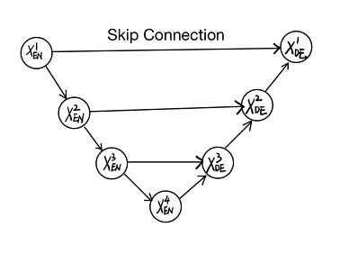

Figure 2.1 Unet Structure

We tried our best to keep enough information for feature maps. For instance, we reduced the depth of the network to four unlike [5] which got five steps since the information of the feature map ($6\times 6$) would be quite limited if we applied the offered images ($96\times 96$) as the input of the Unet with depth five. Similarly, the padding included in each convolution avoided size reduction for the same reason, which means that only max pooling operation would change the size of images.

```python
import matplotlib.pyplot as plt
```

### Unet 3+

While Unet 2+ gets a progress on medical image segmentation accuracy, the nested and dense skip connection architecture rises the quantity of parameters. However, the idea of combining different features of each layer inspires the Unet 3+.

Comparing to Unet, Unet 3+ utilizing bilinear interpolation for upsampling instead of inverse convolution in Unet, which is a data augmentation approach improves boundary smoothness of image .

What’s more, the biggest difference between Unet and Unet 3+ is that Unet 3+ implements the full-scale skip connection [3]. Full-scale skip connection enhances the information capture ability in full scales and remain the channel (which is 256 in our Unet 3+) of the feature map in the decoder.

Fig. 2.2 showcases the interconnection between the encoder and $X_{DE}^2$ as well as the interconnection between the decoder sub-networks and $X_{DE}^2$ . Similar to Unet, $X_{DE}^2$ can receive the feature map from same-scale encoder layer $X_{EN}^2$ , while the information from low-scale in the encoder $X_{EN}^1$ which gains by non-overlapping Max-pooling can also be received by $X_{DE}^2$ through the encoder-decoder skip connection, which is differ from Unet. While the interconnection between each neural in decoder can transmit feature map from larger-scale generates by bilinear augmentation in the decoder $X_{DE}^3$ and $X_{DE}^4$ to $X_{DE}^2$.

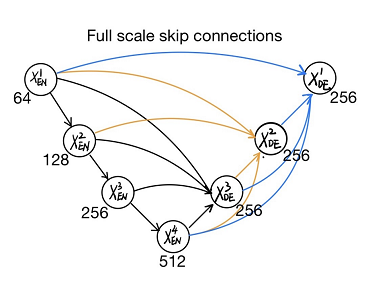

Figure 2.2 Unet 3+ Structure

```python
## Unet 3+ code impl

# -*- coding: utf-8 -*-
import torch
import torch.nn as nn
import torch.nn.functional as F


class unetConv2(nn.Module):
    def __init__(self, in_size, out_size, is_batchnorm, n=2, ks=3, stride=1, padding=1):
        super(unetConv2, self).__init__()
        self.n = n
        self.ks = ks
        self.stride = stride
        self.padding = padding
        s = stride
        p = padding
        if is_batchnorm:
            for i in range(1, n + 1):
                conv = nn.Sequential(nn.Conv2d(in_size, out_size, ks, s, p),
                                     nn.BatchNorm2d(out_size),
                                     nn.ReLU(inplace=True), )
                setattr(self, 'conv%d' % i, conv)
                in_size = out_size

        else:
            for i in range(1, n + 1):
                conv = nn.Sequential(nn.Conv2d(in_size, out_size, ks, s, p),
                                     nn.ReLU(inplace=True), )
                setattr(self, 'conv%d' % i, conv)
                in_size = out_size

    def forward(self, inputs):
        x = inputs
        for i in range(1, self.n + 1):
            conv = getattr(self, 'conv%d' % i)
            x = conv(x)
        return x

'''
    UNet 3+
'''
class UNet_3Plus(nn.Module):
    """
    Our Unet_3Plus, 4 depth
    """
    def __init__(self, in_channels=1, n_classes=4, is_batchnorm=True):
        super(UNet_3Plus, self).__init__()
        self.in_channels = in_channels
        self.is_batchnorm = is_batchnorm

        filters = [64, 128, 256, 512]

        ## -------------Encoder--------------
        self.conv1 = unetConv2(self.in_channels, filters[0], self.is_batchnorm)
        self.maxpool1 = nn.MaxPool2d(kernel_size=2)

        self.conv2 = unetConv2(filters[0], filters[1], self.is_batchnorm)
        self.maxpool2 = nn.MaxPool2d(kernel_size=2)

        self.conv3 = unetConv2(filters[1], filters[2], self.is_batchnorm)
        self.maxpool3 = nn.MaxPool2d(kernel_size=2)

        self.conv4 = unetConv2(filters[2], filters[3], self.is_batchnorm)
        self.maxpool4 = nn.MaxPool2d(kernel_size=2)

        ## -------------Decoder--------------
        self.CatChannels = filters[0]
        self.CatBlocks = 4
        self.UpChannels = self.CatChannels * self.CatBlocks

        '''stage 3d'''
        # h1->96x96, hd3->24x24, Pooling 4 times
        self.h1_PT_hd3 = nn.MaxPool2d(4, 4, ceil_mode=True)
        self.h1_PT_hd3_conv = nn.Conv2d(filters[0], self.CatChannels, 3, padding=1)
        self.h1_PT_hd3_bn = nn.BatchNorm2d(self.CatChannels)
        self.h1_PT_hd3_relu = nn.ReLU(inplace=True)

        # h2->48x48, hd3->24x24, Pooling 2 times
        self.h2_PT_hd3 = nn.MaxPool2d(2, 2, ceil_mode=True)
        self.h2_PT_hd3_conv = nn.Conv2d(filters[1], self.CatChannels, 3, padding=1)
        self.h2_PT_hd3_bn = nn.BatchNorm2d(self.CatChannels)
        self.h2_PT_hd3_relu = nn.ReLU(inplace=True)

        # h3->24x24, hd3->24x24, Concatenation
        self.h3_Cat_hd3_conv = nn.Conv2d(filters[2], self.CatChannels, 3, padding=1)
        self.h3_Cat_hd3_bn = nn.BatchNorm2d(self.CatChannels)
        self.h3_Cat_hd3_relu = nn.ReLU(inplace=True)

        # hd4->12x12, hd3->24x24, Upsample 2 times
        self.hd4_UT_hd3 = nn.Upsample(scale_factor=2, mode='bilinear', align_corners=False)  # 14*14
        self.hd4_UT_hd3_conv = nn.Conv2d(filters[3], self.CatChannels, 3, padding=1)
        self.hd4_UT_hd3_bn = nn.BatchNorm2d(self.CatChannels)
        self.hd4_UT_hd3_relu = nn.ReLU(inplace=True)

        # fusion(h1_PT_hd3, h2_PT_hd3, h3_Cat_hd3, hd4_UT_hd3)
        self.conv3d_1 = nn.Conv2d(self.UpChannels, self.UpChannels, 3, padding=1)  # 16
        self.bn3d_1 = nn.BatchNorm2d(self.UpChannels)
        self.relu3d_1 = nn.ReLU(inplace=True)

        '''stage 2d'''
        # h1->96x96, hd2->48x48, Pooling 2 times
        self.h1_PT_hd2 = nn.MaxPool2d(2, 2, ceil_mode=True)
        self.h1_PT_hd2_conv = nn.Conv2d(filters[0], self.CatChannels, 3, padding=1)
        self.h1_PT_hd2_bn = nn.BatchNorm2d(self.CatChannels)
        self.h1_PT_hd2_relu = nn.ReLU(inplace=True)

        # h2->48x48, hd2->48x48, Concatenation
        self.h2_Cat_hd2_conv = nn.Conv2d(filters[1], self.CatChannels, 3, padding=1)
        self.h2_Cat_hd2_bn = nn.BatchNorm2d(self.CatChannels)
        self.h2_Cat_hd2_relu = nn.ReLU(inplace=True)

        # hd3->24x24, hd2->48x48, Upsample 2 times
        self.hd3_UT_hd2 = nn.Upsample(scale_factor=2, mode='bilinear', align_corners=False)  # 14*14
        self.hd3_UT_hd2_conv = nn.Conv2d(self.UpChannels, self.CatChannels, 3, padding=1)
        self.hd3_UT_hd2_bn = nn.BatchNorm2d(self.CatChannels)
        self.hd3_UT_hd2_relu = nn.ReLU(inplace=True)

        # hd4->12x12, hd2->48x48, Upsample 4 times
        self.hd4_UT_hd2 = nn.Upsample(scale_factor=4, mode='bilinear', align_corners=False)  # 14*14
        self.hd4_UT_hd2_conv = nn.Conv2d(filters[3], self.CatChannels, 3, padding=1)
        self.hd4_UT_hd2_bn = nn.BatchNorm2d(self.CatChannels)
        self.hd4_UT_hd2_relu = nn.ReLU(inplace=True)

        # fusion(h1_PT_hd2, h2_Cat_hd2, hd3_UT_hd2, hd4_UT_hd2)
        self.conv2d_1 = nn.Conv2d(self.UpChannels, self.UpChannels, 3, padding=1)  # 16
        self.bn2d_1 = nn.BatchNorm2d(self.UpChannels)
        self.relu2d_1 = nn.ReLU(inplace=True)

        '''stage 1d '''
        # h1->96x96, hd1->96x96, Concatenation
        self.h1_Cat_hd1_conv = nn.Conv2d(filters[0], self.CatChannels, 3, padding=1)
        self.h1_Cat_hd1_bn = nn.BatchNorm2d(self.CatChannels)
        self.h1_Cat_hd1_relu = nn.ReLU(inplace=True)

        # hd2->48x48, hd1->96x96, Upsample 2 times
        self.hd2_UT_hd1 = nn.Upsample(scale_factor=2, mode='bilinear', align_corners=False)  # 14*14
        self.hd2_UT_hd1_conv = nn.Conv2d(self.UpChannels, self.CatChannels, 3, padding=1)
        self.hd2_UT_hd1_bn = nn.BatchNorm2d(self.CatChannels)
        self.hd2_UT_hd1_relu = nn.ReLU(inplace=True)

        # hd3->24x24, hd1->96x96, Upsample 4 times
        self.hd3_UT_hd1 = nn.Upsample(scale_factor=4, mode='bilinear', align_corners=False)  # 14*14
        self.hd3_UT_hd1_conv = nn.Conv2d(self.UpChannels, self.CatChannels, 3, padding=1)
        self.hd3_UT_hd1_bn = nn.BatchNorm2d(self.CatChannels)
        self.hd3_UT_hd1_relu = nn.ReLU(inplace=True)

        # hd4->12x12, hd1->96x96, Upsample 8 times
        self.hd4_UT_hd1 = nn.Upsample(scale_factor=8, mode='bilinear', align_corners=False)  # 14*14
        self.hd4_UT_hd1_conv = nn.Conv2d(filters[3], self.CatChannels, 3, padding=1)
        self.hd4_UT_hd1_bn = nn.BatchNorm2d(self.CatChannels)
        self.hd4_UT_hd1_relu = nn.ReLU(inplace=True)

        # fusion(h1_Cat_hd1, hd2_UT_hd1, hd3_UT_hd1, hd4_UT_hd1)
        self.conv1d_1 = nn.Conv2d(self.UpChannels, self.UpChannels, 3, padding=1)  # 16
        self.bn1d_1 = nn.BatchNorm2d(self.UpChannels)
        self.relu1d_1 = nn.ReLU(inplace=True)

        # output
        self.outconv1 = nn.Conv2d(self.UpChannels, n_classes, 3, padding=1)
        self.out = torch.nn.Sequential(
                self.outconv1,
                )

    def forward(self, inputs):
        ## -------------Encoder-------------
        h1 = self.conv1(inputs)  # h1->96x96x64

        h2 = self.maxpool1(h1)
        h2 = self.conv2(h2)  # h2->48x48x128

        h3 = self.maxpool2(h2)
        h3 = self.conv3(h3)  # h3->24x24x256

        h4 = self.maxpool3(h3)
        hd4 = self.conv4(h4)  # h4->12x12x512

        ## -------------Decoder-------------
        h1_PT_hd3 = self.h1_PT_hd3_relu(self.h1_PT_hd3_bn(self.h1_PT_hd3_conv(self.h1_PT_hd3(h1))))
        h2_PT_hd3 = self.h2_PT_hd3_relu(self.h2_PT_hd3_bn(self.h2_PT_hd3_conv(self.h2_PT_hd3(h2))))
        h3_Cat_hd3 = self.h3_Cat_hd3_relu(self.h3_Cat_hd3_bn(self.h3_Cat_hd3_conv(h3)))
        hd4_UT_hd3 = self.hd4_UT_hd3_relu(self.hd4_UT_hd3_bn(self.hd4_UT_hd3_conv(self.hd4_UT_hd3(hd4))))
        hd3 = self.relu3d_1(self.bn3d_1(self.conv3d_1(
            torch.cat((h1_PT_hd3, h2_PT_hd3, h3_Cat_hd3, hd4_UT_hd3), 1)))) # hd3->24x24xUpChannels

        h1_PT_hd2 = self.h1_PT_hd2_relu(self.h1_PT_hd2_bn(self.h1_PT_hd2_conv(self.h1_PT_hd2(h1))))
        h2_Cat_hd2 = self.h2_Cat_hd2_relu(self.h2_Cat_hd2_bn(self.h2_Cat_hd2_conv(h2)))
        hd3_UT_hd2 = self.hd3_UT_hd2_relu(self.hd3_UT_hd2_bn(self.hd3_UT_hd2_conv(self.hd3_UT_hd2(hd3))))
        hd4_UT_hd2 = self.hd4_UT_hd2_relu(self.hd4_UT_hd2_bn(self.hd4_UT_hd2_conv(self.hd4_UT_hd2(hd4))))
        hd2 = self.relu2d_1(self.bn2d_1(self.conv2d_1(
            torch.cat((h1_PT_hd2, h2_Cat_hd2, hd3_UT_hd2, hd4_UT_hd2), 1)))) # hd2->48x48xUpChannels

        h1_Cat_hd1 = self.h1_Cat_hd1_relu(self.h1_Cat_hd1_bn(self.h1_Cat_hd1_conv(h1)))
        hd2_UT_hd1 = self.hd2_UT_hd1_relu(self.hd2_UT_hd1_bn(self.hd2_UT_hd1_conv(self.hd2_UT_hd1(hd2))))
        hd3_UT_hd1 = self.hd3_UT_hd1_relu(self.hd3_UT_hd1_bn(self.hd3_UT_hd1_conv(self.hd3_UT_hd1(hd3))))
        hd4_UT_hd1 = self.hd4_UT_hd1_relu(self.hd4_UT_hd1_bn(self.hd4_UT_hd1_conv(self.hd4_UT_hd1(hd4))))
        hd1 = self.relu1d_1(self.bn1d_1(self.conv1d_1(
            torch.cat((h1_Cat_hd1, hd2_UT_hd1, hd3_UT_hd1, hd4_UT_hd1), 1)))) # hd1->96x96xUpChannels

        d1 = self.out(hd1)  # d1->96x96xn_classes
        return d1
```

### Performance analysis mechanism

Totally five mechanisms we chose for analyzing performance:

- a).cross entropy
- b).dice loss
- c).epoch time
- d).model size
- e).noise number

Cross entropy is our first choice at the beginning since not only it is a classic loss function of classification problem, but also derivable, which is the determining factor of backpropagation. However, there is no remarkable inter-dependency between cross entropy and dice that is the analysis mechanism on Kaggle, especially when the accuracy of dice rose more than 85%, the further reducing of cross entropy’s loss did not make dice perform better. So the cross entropy was not our main loss function for analysis.

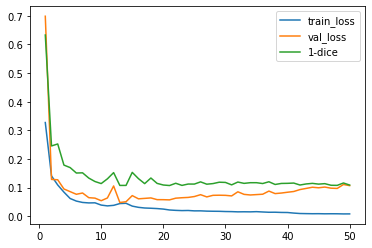

Figure2.3 val loss and val dice graph

Although dice plays an important role in training and validation, for choosing a well-performance model by calculating the intersection ratio between the overlap area and the average area of ground truth mask and predicted mask, the original dice function transform each probability into separate index and it is not able to satisfy the condition of backpropagation.

$$ourdice = \frac{|A*B|}{(|A|+|B|)/2}$$

Therefore, our group rebuilt the dice function that we called Our_Dice(dice-like) function since the loss function for this course work should be derivable and highly correlative with the evaluation mechanism of Kaggle.

The format of Our_Dice is identical to the normal dice. Item A is defined as the predicted result, it is a tensor with size $4\times 96\times 96$ and the value for each pixel in different channel is float number represents the probability of that pixel belongs to current channel’s class.

Item B indicates the tensor of the ground truth mask with size $4\times 96\times 96$ which its original size was $1\times 96\times 96$ and transformed by torch.nn.functional.one_hot function. The value of pixel in each channel is either 0 or 1, which showcased that whether this pixel belongs to current category represented by present channel. For example, in channel 1, if one pixel’s value is 1, the other three values of pixels in different channel with same location are 0, which means in the original mask, this pixel belongs to class 1.

The numerator is a result of the product between A and B which is a 4-dimension tensor means the overlapping area between them. For the denominator, it is a 4-dimension tensor too, each value in different dimension is an average of the sum of the predicted pixels’ probability and the sum of the classification flag (0 or 1) of ground truth mask after size transformed. Unlike the origin dice that filters pixels’ value with low possibility which belong to one class, our_dice calculates with all the possibilities of every pixel which maintains the continuity of the function and makes backpropagation available.

Noticing that the dice loss is the difference of 1 and the value of dice or our_dice. If no special comment, the loss we called below (dice loss and our_dice loss) is the difference we mentioned as above:

```python
## Ourdice code

def _softdice(pred, target):
    """
    Args:
        pred (Tensor) : shape (N, C, H, W), where N is the batch size, C is the number of channel,
            H and W is the height and width of each image.
        target (Tensor) : shape (N, H, W), where N, H, W is the same meanning of above.
    """

    # batch size
    b = pred.shape[0]
    #  target = target.long()
    dice = 0.0

    # compute dice of each image
    for i in range(0, b):
        # noticed that the shape of one_hot(target[i], num_classes=4) is [96, 96, 4], (H, W, C),
        # in order to get the same shape with pred[i] [4, 96, 96], (C, H, W),
        # we should apply a permute(2, 0, 1), which transform (H, W, C) to (C, H, W)
        mask = F.one_hot(target[i], num_classes=4).permute(2, 0, 1)

        # the channel is the probability of each class, so we apply a softmax in dims C
        predi = pred[i].softmax(0)

        # sum((1, 2)) means sum in dims H and W, but not channel
        # the shape of both frac{1, 2} is C
        frac1 = ((mask * predi).sum((1, 2)))           # |A * B|
        frac2 = mask.sum((1, 2)) + predi.sum((1, 2))   # |A|+|B|

        # we (kaggle) dont use the dice of background, which index is 0
        # thus the index is [1:]
        result = 2 * (frac1 / frac2)[1:].mean()
        dice += result
    return 1 - dice / b


class SoftDice(torch.nn.Module):
    def __init__(self):
        super(SoftDice, self).__init__()

    def forward(self, pred, target):
        return _softdice(pred, target)
```

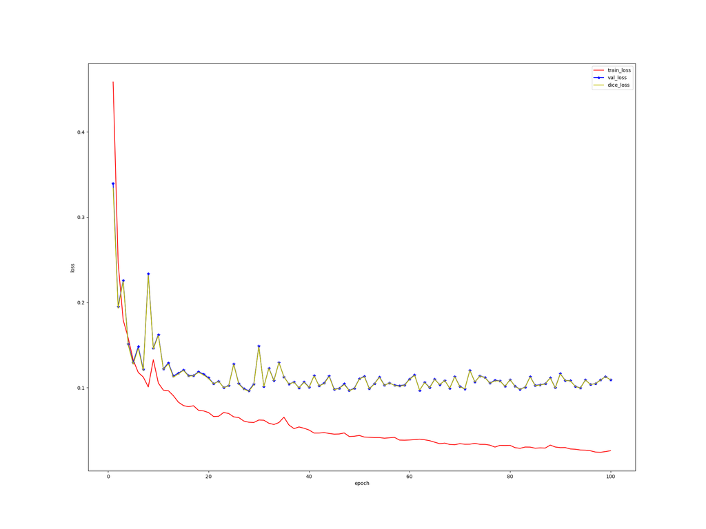

Figure2.4 val loss and val dice graph

Besides, both epoch time and model size are an intuitive way to recognize the computational cost of model. And the inference accuracy of models can be measured by the noise number.

## Experiment

Our experiment details as below. For different experiments, there will be a table for comparing different performance of models which displays various factors, like architecture depth, loss function, dataset and so on.

### SegNet

For the SgeNet experiment, we need to set some hyperparameters for training, like epoch, batch_size, learning rate and momentum. We preferred Stochastic Gradient Descent to be the optimizer which is a good optimization algorithm for cross entropy loss function. Before training, we loaded the pre-trained model of VGG16 for reducing calculation cost.

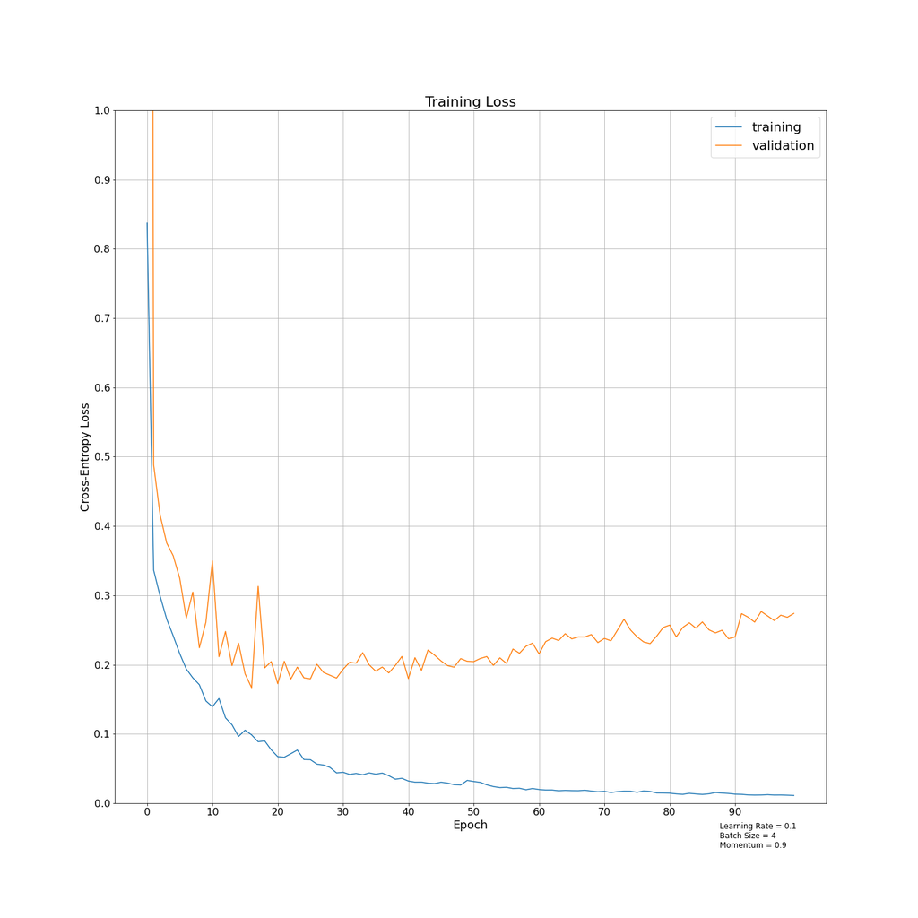

Figure3.1 SegNet Loss curve

| **Variable** | **Result** |
| --- | --- |
| Architecture depth | 13 |
| Loss function | Cross entropy |
| Dataset | Original dataset |
| Optimizer | SGD |
| Learning rate | 0.1 |
| Momentum | 0.9 |
| Size of model | About 112.4M |
| Accuracy | About 0.71 |

### Unet

As to Unet experiment, noticing that the size of model got a extremely decrease, but the segmentation accuracy is lower than our expected to Unet.

| **Variable** | **Result** |
| --- | --- |
| Architecture depth | 4 |
| Loss function | Cross entropy |
| Dataset | Original dataset |
| Optimizer | Adam |
| Learning rate | 0.001 |
| Size of model | About 30M |
| Accuracy | About 0.84 |

### Unet 3+

For the first experiment of Unet 3+, as we can see that the accuracy got a slightly improve while the size of model did not become larger.

| **Variable** | **Result** |
| --- | --- |
| Architecture depth | 4 |
| Loss function | Cross entropy |
| Dataset | Original dataset |
| Optimizer | Adam |
| Learning rate | 0.001 |
| Size of model | About 30M |
| Accuracy | About 0.86 |

After replacing the loss function to our_dice loss, the result become better.

| **Variable** | **Result** |
| --- | --- |
| Architecture depth | 4 |
| Loss function | ourdice |
| Dataset | Original dataset |
| Optimizer | Adam |
| Learning rate | 0.001 |
| Size of model | About 30M |
| Accuracy | About 0.88 |

| **Variable** | **Result** |
| --- | --- |
| Architecture depth | 4 |
| Loss function | ourdice |
| Dataset | Apply data augmentation |
| Optimizer | Adam |
| Learning rate | 0.001 |
| Size of model | About 30M |
| Accuracy | About 0.903 |

````python
### Dataset

class TrainDataset(data.Dataset):
    """
    The Dataset for trainning set.
    In order to improve the accuracy, we used some method for aata augmentation,
    thus the structure of trainning sets' directory has been modified, and now
    it has the form

    ```
    train
    ├── brightness
    │   ├── cmr1.png
    │   ├── ...
    │   └── cmr100.png
    ├── brightness_mask
    │   ├── cmr1_mask.png
    │   ├── ...
    │   └── cmr100_mask.png
    ├── ...
    ├── image
    ├── image_mask
    ├── ...
    ├── vertical
    └── vertical_mask
    ```

    while the raw `mask` dir is now `image_mask`, and for augmentation xxx,
    the xxx dir stored the picture transformed and xxx_mask dir stored the
    picture's mask, respectively.
    """
    def __init__(self, root='', select_dir=None):
        """
        Constructor of TrainDataset

        Args:
            root (str), the root directory of trainning dataset
            select_dir (list[str], optional) :indicating which sub dir of
                data augmentation should be selected.
        """

        super(TrainDataset, self).__init__()

        # select_dir == None
        if not select_dir:
            select_dir = [
                'image',
                'rotate',
                'vertical',
                'horizontal',
                'brightness',
                'contrast',
                # 'sharpness',
                'saturation'
            ]

        ## all valid sub directory, if there is a dir `sharpness` without `sharpness_mask`,
        ## it is a invalid directory and will not be selected.
        self.img_dir = map(lambda s: s[:-5], glob(os.path.join(root, '*_mask')))
        ## select needed sub directory in above
        self.img_dir = filter(lambda dir: os.path.basename(dir) in select_dir, self.img_dir)

        self.img_files = []
        self.mask_files = []

        ## match all png file in each sub directory
        for dir in self.img_dir:
            img_lst = glob(os.path.join(dir, '*.png'))
            self.img_files += img_lst

        ## append the corresponding mask to mask_files
        for img_path in self.img_files:
            basename = os.path.basename(img_path)
            dirname = os.path.dirname(img_path)

            #  train             mask     train
            #  └── brightness   --------> └── brightness_mask
            #      └── cmr1.png               └── cmr1_mask.png
            self.mask_files.append(os.path.join(dirname +'_mask',basename[:-4]+'_mask.png'))



    def __getitem__(self, index):
        img_path = self.img_files[index]
        mask_path = self.mask_files[index]
        img = cv2.imread(img_path, cv2.IMREAD_UNCHANGED)
        label = cv2.imread(mask_path, cv2.IMREAD_UNCHANGED)
        return torch.from_numpy(img).float(), torch.from_numpy(label).float()

    def __len__(self):
        return len(self.img_files)

class ValDataset(data.Dataset):
    """
    Raw dataset for validation without any modifying
    val
    ├── image
    └── mask
    """
    def __init__(self, root=''):
        super(ValDataset, self).__init__()
        self.img_files = glob(os.path.join(root,'image','*.png'))
        self.mask_files = []
        for img_path in self.img_files:
            basename = os.path.basename(img_path)
            self.mask_files.append(os.path.join(root,'mask',basename[:-4]+'_mask.png'))


    def __getitem__(self, index):
        img_path = self.img_files[index]
        mask_path = self.mask_files[index]
        img = cv2.imread(img_path, cv2.IMREAD_UNCHANGED)
        label = cv2.imread(mask_path, cv2.IMREAD_UNCHANGED)
        return torch.from_numpy(img).float(), torch.from_numpy(label).float()

    def __len__(self):
        return len(self.img_files)

class TestDataset(data.Dataset):
    """
    Raw dataset for testing without any modifying
    test
    ├── image
    └── mask (empty)
    """
    def __init__(self, root=''):
        super(TestDataset, self).__init__()
        self.img_files = glob(os.path.join(root,'image','*.png'))

    def __getitem__(self, index):
        img_path = self.img_files[index]
        data = cv2.imread(img_path, cv2.IMREAD_UNCHANGED)
        return torch.from_numpy(data).float()

    def __len__(self):
        return len(self.img_files)
````

Finally, we tried to add one more layer to get a better performance of feature extraction. As you can see on the table, the accuracy did rise but the cost of calculation also increase which can be reflected on the size of model.

| **Variable** | **Result** |
| --- | --- |
| Architecture depth | 5 |
| Loss function | ourdice |
| Dataset | Apply data augmentation |
| Optimizer | Adam |
| Learning rate | 0.001 |
| Size of model | About 110M |
| Accuracy | About 0.908 |

```python
### Main code

from glob import glob
import os
import argparse

import numpy as np
import matplotlib.pyplot as plt
import cv2
import torch
from torch.utils.data import DataLoader
from tqdm.notebook import tqdm


from UNet.UNet3Plus import UNet_3Plus
from UNet.Dataset import TrainDataset, TestDataset, ValDataset
from UNet.loss import SoftDice

device = 'cuda' if torch.cuda.is_available() else 'cpu'

## use cudnn benchmark to help cudnn find fastest method when conv
if device == 'cuda':
   torch.backends.cudnn.benchmark = True

### In order to run either in jupyter or in command line, this function help us parse args.
def parse(cmd: str=None):
    """parse(cmd)
    cmd: [-h] {train,test} ...

    positional arguments:
      {train,test}  command help
        train       Trainning the model
        test        Test the model

    optional arguments:
      -h, --help    show this help message and exit


    cmd: train [-h] [-o OUTPUT] [--lr LR]
                                       [--epochs EPOCHS] [-s SIZE] [--load]
                                       [-i INPUT] [-l {cross,ourdice}]

    optional arguments:
      -h, --help            show this help message and exit
      -o OUTPUT, --output OUTPUT
                            Save the model to a file
      --lr LR               learning rate
      --epochs EPOCHS       epochs
      -s SIZE, --size SIZE  Padding or crop to size
      --load                Loading params before trainning
      -i INPUT, --input INPUT
                            Loading from file
      -l {cross,ourdice}, --loss {cross,ourdice}
                            Loss function

    cmd: test [-h] [-s SIZE] [-i INPUT] {test,train,val}

    positional arguments:
      {test,train,val}      Data to load

    optional arguments:
      -h, --help            show this help message and exit
      -s SIZE, --size SIZE  Padding or crop to size
      -i INPUT, --input INPUT
                            Loading a model and then test
    """
    parser = argparse.ArgumentParser()
    subparers = parser.add_subparsers(help='command help')

    train_parser = subparers.add_parser('train', help='Trainning the model')
    train_parser.add_argument(
            '-o',
            '--output',
            help='Save the model to a file',
            type=str,
            default='./unet_net.pth'
            )
    train_parser.add_argument(
            '--lr',
            help='learning rate',
            type=float
            )
    train_parser.add_argument(
            '--epochs',
            help='epochs',
            type=int
            )
    train_parser.add_argument(
            '-s',
            '--size',
            help='Padding or crop to size',
            type=int
            )
    train_parser.add_argument(
            '--load',
            help='Loading params before trainning',
            action="store_true"
            )
    train_parser.add_argument(
            '-i',
            '--input',
            help='Loading from file',
            type=str
            )
    train_parser.add_argument(
            '-l',
            '--loss',
            help='Loss function',
            choices=['cross', 'ourdice']
            )
    train_parser.set_defaults(func=train)


    test_parser = subparers.add_parser('test', help='Test the model')
    test_parser.add_argument(
            'data',
            help='Data to load',
            choices=['test', 'train', 'val']
            )
    test_parser.add_argument(
            '-s',
            '--size',
            help='Padding or crop to size',
            type=int
            )
    test_parser.add_argument(
            '-i',
            '--input',
            help='Loading a model and then test',
            type=str,
            default='./unet_net.pth'
            )
    test_parser.set_defaults(func=test_model)


    args = parser.parse_args(cmd.split(' '))
    args.func(args)


def train(args):
    ## set default args
    output_file = args.output or './unet_net.pth'
    epochs      = args.epochs or 200
    lr          = args.lr     or 1e-3
    size        = args.size   or 96
    unet        = UNet_3Plus().to(device)
    lossfun     = args.loss
    ## if use "--load", load pre trained parameters first.
    if args.load:
        input_file = args.input or output_file
        unet.load_state_dict(torch.load(input_file))

    training_data_loader: DataLoader = load_data('./train')
    val_data_loader: DataLoader      = load_data_val('./CW/data/val')

    train_loss_array = []
    val_loss_array   = []
    val_dice_array   = []
    max_dice         = -1.

    criterion = SoftDice() if lossfun == 'ourdice' else torch.nn.CrossEntropyLoss()
    optimizer = torch.optim.Adam(unet.parameters(), lr=lr)
    scheduler = torch.optim.lr_scheduler.StepLR(optimizer, step_size=20, gamma=0.5)

    ### start training
    try:
        for epoch in tqdm(range(epochs), position=1):
            unet.train()
            train_loss   = 0.
            train_sample = 0
            for sample in tqdm(training_data_loader, leave=False, position=0):
                img, mask = sample
                img  = img.to(device).unsqueeze(1)
                mask = mask.to(device)

                optimizer.zero_grad()
                outputs = unet(img)
                loss    = criterion(outputs, mask.long())
                loss.backward()
                optimizer.step()
                train_loss   += loss.item() * img.shape[0]
                train_sample += img.shape[0]
            scheduler.step()

            ## we dont need these outside the for loop, del them to ensure they will collected by gc.
            del img
            del mask
            del loss

            ## print train loss, val loss, val dice and save parameters
            if (epoch+1) % 1 == 0:
                unet.eval()
                val_loss   = 0.
                val_sample = 0
                val_dice   = 0.

                ## we dont need to calculate grad in eval mode
                ## this can help us save some memory and time
                with torch.no_grad():
                    for img, mask in val_data_loader:
                        img         = img.to(device).unsqueeze(1)
                        mask        = mask.to(device)
                        loss        = criterion(unet(img), mask.long())
                        val_loss   += loss.item() * img.shape[0]
                        val_sample += img.shape[0]
```

```python
                        ## compute kaggle dice of each image
                        for i in range(img.shape[0]):
                            output     = unet(img[i].unsqueeze(0))
                            output     = output.argmax(dim=1)
                            val_dice  += dice_loss_total(output.squeeze(), mask[i].squeeze())

                    train_loss_average = train_loss / train_sample
                    val_loss_average   = val_loss   / val_sample
                    val_dice_average   = val_dice   / val_sample

                    train_loss_array.append(train_loss_average)
                    val_loss_array  .append(val_loss_average)
                    val_dice_array  .append(val_dice_average)

                    tqdm.write("==================================================")
                    tqdm.write("Average train loss in epoch %d: %f" % (epoch+1, train_loss_average))
                    tqdm.write("Average val   loss in epoch %d: %f" % (epoch+1, val_loss_average  ))
                    tqdm.write("Average val   dice in epoch %d: %f" % (epoch+1, val_dice_average  ))

                #if val_dice > max_dice:
                if True:
                    max_dice = val_dice
                    torch.save(unet.state_dict(), output_file[:-4] + str(epoch+1) + output_file[-4:])

    ## when interrupt by keyboard, e.g. Ctrl+c, save loss and dice to file
    except KeyboardInterrupt:
        result = np.array([train_loss_array,
                          val_loss_array,
                          val_dice_array])
        np.savetxt('./result.csv', result, delimiter=',')
    else:
        result = np.array([train_loss_array,
                          val_loss_array,
                          val_dice_array])
        np.savetxt('./result.csv', result, delimiter=',')
        torch.save(unet.state_dict(), output_file)

def test_model(args):
    unet = UNet_3Plus(in_channels=1, n_classes=4, is_batchnorm=True)
    unet.load_state_dict(torch.load(args.input))

    if args.data == 'test':
        ## image in testing set cmr121.png .. cmr200.png
        fileindex = 121
        data_loader: DataLoader = load_data_test('./CW/data/'+args.data)
        unet.eval()
        for iteration, sample in enumerate(data_loader):
            imgList = sample

            ## print and save each image in a batch
            for i in range(imgList.shape[0]):
                img: torch.Tensor = imgList[i]
                image = img
                with torch.no_grad():
                    output = unet(image.unsqueeze(0).unsqueeze(0))
                    output = output.argmax(dim=1)

                ## (raw image, predict mask)
                plt.figure(figsize=(6,3))
                plt.subplot(1, 2, 1)
                plt.imshow(img, cmap='gray')
                plt.axis('off')
                plt.subplot(1, 2, 2)
                plt.imshow(output.squeeze(), cmap='gray')
                plt.axis('off')

                plt.show()

                ## save
                cv2.imwrite('./mask/cmr'+str(fileindex)+'_mask.png', output.squeeze().numpy())
                fileindex += 1
    else:
        if args.data == 'test':
            data_loader: DataLoader = load_data('./train/')
        else:
            data_loader: DataLoader = load_data_val('./CW/data/'+args.data)
        unet.eval()
        for iteration, sample in enumerate(data_loader):
            imgList, maskList = sample

            ## print  each image in a batch
            for i in range(imgList.shape[0]):
                img: torch.Tensor = imgList[i]
                image = img
                mask = maskList[i]
                with torch.no_grad():
                    output = unet(image.unsqueeze(0).unsqueeze(0))
                    output = output.argmax(dim=1)

                ## (raw image, predict mask, ground truth)
                plt.figure(figsize=(6,3))
                plt.subplot(1, 3, 1)
                plt.imshow(img, cmap='gray')
                plt.axis('off')
                plt.subplot(1, 3, 2)
                plt.imshow(mask, cmap='gray')
                plt.axis('off')
                plt.subplot(1, 3, 3)
                plt.imshow(output.squeeze(), cmap='gray')
                plt.axis('off')
                plt.show()


def load_data(data_path: str, num_workers=4, batch_size=8, shuffle=True) -> DataLoader:
    print("Loading data from %s" % data_path)
    train_set = TrainDataset(data_path, select_dir=[
        'image',
        'rotate',
        # 'vertical',
        'horizontal',
        'brightness',
        'contrast',
        # 'sharpness',
         # 'saturation'
    ])
    return DataLoader(
            dataset     = train_set,
            num_workers = num_workers,
            batch_size  = batch_size,
            shuffle     = shuffle
            )
def load_data_test(data_path: str, num_workers=4, batch_size=4, shuffle=False) -> DataLoader:
    print("Loading data from %s" % data_path)
    train_set = TestDataset(data_path)
    return DataLoader(
            dataset     = train_set,
            num_workers = num_workers,
            batch_size  = batch_size,
            shuffle     = shuffle
            )
def load_data_val(data_path: str, num_workers=4, batch_size=4, shuffle=False) -> DataLoader:
    print("Loading data from %s" % data_path)
    train_set = ValDataset(data_path)
    return DataLoader(
            dataset     = train_set,
            num_workers = num_workers,
            batch_size  = batch_size,
            shuffle     = shuffle
            )

### mask1: predict
### mask2: mask
def categorical_dice(mask1, mask2, label_class):
    mask1 = mask1.long()
    mask2 = mask2.long()
    mask1_pos = (mask1 == label_class)
    mask2_pos = (mask2 == label_class)
    dice = 2 * (mask1_pos * mask2_pos).sum() / (mask1_pos.sum() + mask2_pos.sum())
    return dice.item()

def dice_loss_total(mask_pre, mask_gt):
    dice_loss = 0.
    for n in range(1, 4):
        dice_loss += categorical_dice(mask_pre, mask_gt, n)
    return dice_loss / 3.
```

```python
### To run training task, just call
parse("train --loss ourdice --epoch 200 --lr 0.001")
```

```
Loading data from ./train
Loading data from ./CW/data/val
```

```
==================================================
Average train loss in epoch 1: 0.466513
Average val   loss in epoch 1: 0.360760
Average val   dice in epoch 1: 0.642387
```

```
==================================================
Average train loss in epoch 2: 0.269293
Average val   loss in epoch 2: 0.317458
Average val   dice in epoch 2: 0.683201
```

```
==================================================
Average train loss in epoch 3: 0.188729
Average val   loss in epoch 3: 0.144612
Average val   dice in epoch 3: 0.857199
```

```
==================================================
Average train loss in epoch 4: 0.168692
Average val   loss in epoch 4: 0.181876
Average val   dice in epoch 4: 0.818555
```

```
==================================================
Average train loss in epoch 5: 0.144565
Average val   loss in epoch 5: 0.140963
Average val   dice in epoch 5: 0.860364
```

```
==================================================
Average train loss in epoch 6: 0.127873
Average val   loss in epoch 6: 0.264386
Average val   dice in epoch 6: 0.736564
```

```
==================================================
Average train loss in epoch 7: 0.126134
Average val   loss in epoch 7: 0.122067
Average val   dice in epoch 7: 0.879445
```

```
==================================================
Average train loss in epoch 8: 0.118889
Average val   loss in epoch 8: 0.122808
Average val   dice in epoch 8: 0.878439
```

```
==================================================
Average train loss in epoch 9: 0.102332
Average val   loss in epoch 9: 0.130283
Average val   dice in epoch 9: 0.870659
```

```
==================================================
Average train loss in epoch 10: 0.095645
Average val   loss in epoch 10: 0.122227
Average val   dice in epoch 10: 0.878845
```

```
==================================================
Average train loss in epoch 11: 0.090548
Average val   loss in epoch 11: 0.130308
Average val   dice in epoch 11: 0.870469
```

```
==================================================
Average train loss in epoch 12: 0.090603
Average val   loss in epoch 12: 0.161755
Average val   dice in epoch 12: 0.839053
```

```
==================================================
Average train loss in epoch 13: 0.122635
Average val   loss in epoch 13: 0.141095
Average val   dice in epoch 13: 0.860060
```

```
==================================================
Average train loss in epoch 14: 0.093065
Average val   loss in epoch 14: 0.121263
Average val   dice in epoch 14: 0.879211
```

```
==================================================
Average train loss in epoch 15: 0.085769
Average val   loss in epoch 15: 0.134578
Average val   dice in epoch 15: 0.865660
```

```
==================================================
Average train loss in epoch 16: 0.079788
Average val   loss in epoch 16: 0.134366
Average val   dice in epoch 16: 0.865522
```

```
==================================================
Average train loss in epoch 17: 0.079165
Average val   loss in epoch 17: 0.147537
Average val   dice in epoch 17: 0.852852
```

```
==================================================
Average train loss in epoch 18: 0.078701
Average val   loss in epoch 18: 0.122419
Average val   dice in epoch 18: 0.878605
```

```
==================================================
Average train loss in epoch 19: 0.073896
Average val   loss in epoch 19: 0.113986
Average val   dice in epoch 19: 0.886861
```

```
==================================================
Average train loss in epoch 20: 0.070791
Average val   loss in epoch 20: 0.119209
Average val   dice in epoch 20: 0.880899
```

```
Loading data from ./CW/data/train
```

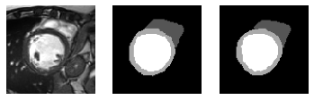

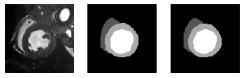

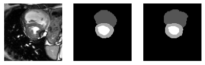

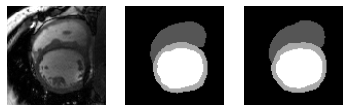

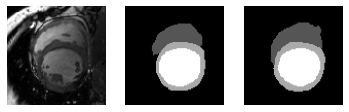

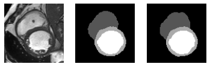

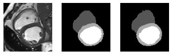

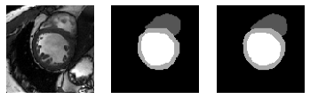

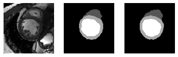

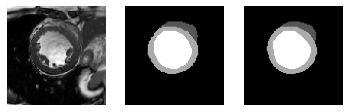

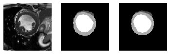

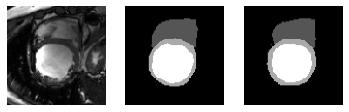

[88 more figures not shown]

```python
### testing model on training dataset
parse("test train -i unet_net20.pth")
```

```
Loading data from ./CW/data/val
```

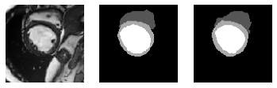

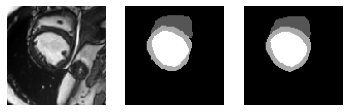

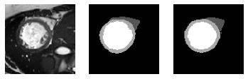

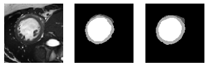

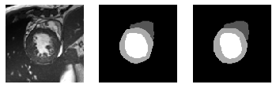

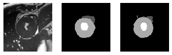

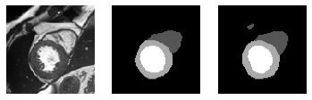

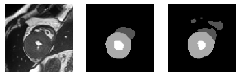

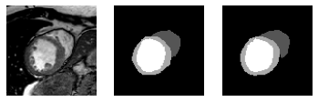

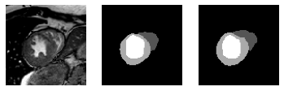

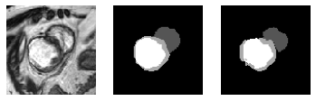

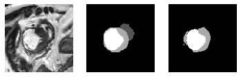

[8 more figures not shown]

```python
### testing model on validation dataset
parse("test val -i unet_net20.pth")
```

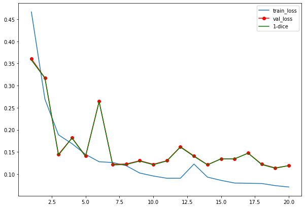

```python
### plotting the loss of training sets, loss of validation sets, and 1-dice of validation sets
import numpy as np
import matplotlib.pyplot as plt
result = np.loadtxt('./result.csv', delimiter=',')
epoch = np.array(range(result.shape[1]))+1

plt.figure(figsize=(10, 7))
## x: epoch, y: train_loss(cross_entropy)
plt.plot(epoch[:], result[0,:], label="train_loss")
## x: epoch, y: val_loss(cross_entropy)
plt.plot(epoch[:], result[1,:], 'r-o',label="val_loss")
## x: epoch, y: 1-kaggle_dice
plt.plot(epoch[:], 1-result[2,:], 'g',label="1-dice")
plt.legend()
plt.show()
```

## Conclusion

In this course work, we implemented various kinds of networks for medical image segmentation and compared the performance. Some key findings as below:

1. Cross entropy is not strictly negative relevant to the value of dice, the best choice for loss function needs to be closely relevant to the Kaggle’s loss. Simply use the difference between 1 and dice as loss function is not acceptable since the way to calculate the dice is not able to derivative.
2. Choosing an appropriate learning rate is important for the model to get a good performance.
3. The data augmentation can improve the generalization of the model.

The best generalization performance can be reflected on the score provided by Kaggle which we got 0.89976 on the test set.

**For the clearly understanding, we would like to upload a zip file which include all sourse file and data.**

## Reference

[1] Badrinarayanan, Vijay, Alex Kendall, and Roberto Cipolla. "Segnet: A deep convolutional encoder-decoder architecture for image segmentation." IEEE transactions on pattern analysis and machine intelligence 39.12 (2017): 2481-2495.

[2] K. Simonyan and A. Zisserman, “Very deep convolutional networks for large-scale image recognition,” arXiv preprint arXiv:1409.1556, 2014

[3] Huang, Huimin & Lin, Lanfen & Tong, Ruofeng & Hu, Hongjie & Qiaowei, Zhang & Iwamoto, Yutaro & Han, Xian-Hua & Chen, Yen-Wei & Wu, Jian. (2020). UNet 3+: A Full-Scale Connected UNet for Medical Image Segmentation.

[4] Chu, Jiajia, Yajie Chen, Wei Zhou, Heshui Shi, Yukun Cao, Dandan Tu, Ri-Chu Jin and Yongchao Xu. “Pay More Attention to Discontinuity for Medical Image Segmentation.” MICCAI (2020).

[5] Ronneberger O, Fischer P, Brox T. U-net: Convolutional networks for biomedical image segmentation[C]//International Conference on Medical image computing and computer-assisted intervention. Springer, Cham, 2015: 234-241.

[6] Long, Jonathan, Evan Shelhamer, and Trevor Darrell. "Fully convolutional networks for semantic segmentation." Proceedings of the IEEE conference on computer vision and pattern recognition. 2015.